# Lab 5

Hunter Finger

March 06, 2019

# Instructions

**Exercises:** 1,3 (Pg. 227); 2 (Pg. 232); 1,2 (Pg. 235);

**Assigned:** Friday, March 1, 2019

**Due:** Friday, March 8, 2019 by 5:00 PM

**Submission:** Submit via an electronic document on Sakai. Must be submitted as a HTML file generated in RStudio. All assigned problems are chosen according to the textbook *R for Data Science*. You do not need R code to answer every question. If you answer without using R code, delete the code chunk. If the question requires R code, make sure you display R code. If the question requires a figure, make sure you display a figure. A lot of the questions can be answered in written response, but require R code and/or figures for understanding and explaining.

# Chapter 12 (Pg. 227)

## Exercise 1

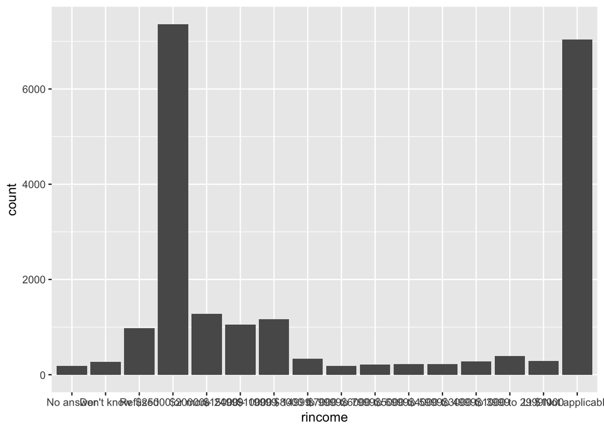

```r
rincome_bar <- gss_cat %>% ggplot(mapping = aes(x = rincome)) + geom_bar()
rincome_bar
```

The bar plot is hard to read because the labels all overlap each other on the x axis. To fix this, I will make the labels verticle.

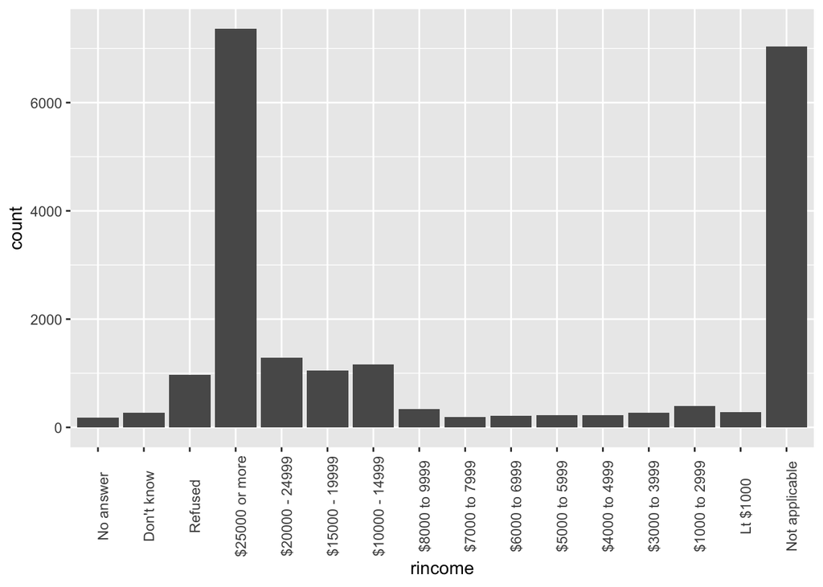

```r
rincome_bar + theme(axis.text.x = element_text(angle = 90))
```

## Exercise 3

```r
levels(gss_cat$denom)
```

```
##  [1] "No answer"            "Don't know"           "No denomination"
##  [4] "Other"                "Episcopal"            "Presbyterian-dk wh"
##  [7] "Presbyterian, merged" "Other presbyterian"   "United pres ch in us"
## [10] "Presbyterian c in us" "Lutheran-dk which"    "Evangelical luth"
## [13] "Other lutheran"       "Wi evan luth synod"   "Lutheran-mo synod"
## [16] "Luth ch in america"   "Am lutheran"          "Methodist-dk which"
## [19] "Other methodist"      "United methodist"     "Afr meth ep zion"
## [22] "Afr meth episcopal"   "Baptist-dk which"     "Other baptists"
## [25] "Southern baptist"     "Nat bapt conv usa"    "Nat bapt conv of am"
## [28] "Am bapt ch in usa"    "Am baptist asso"      "Not applicable"
```

The denom column is tied to the Protestant relig. Using the table, showing the levels of denom, it is clear the column is connected with the Protestant religion.

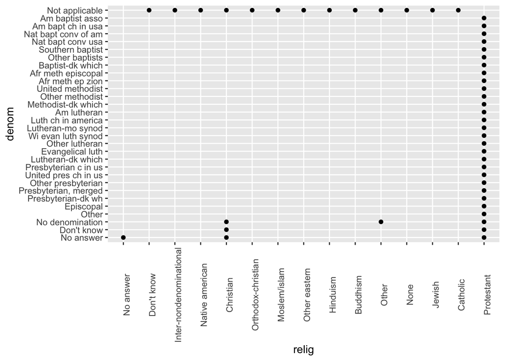

```r
denom_vis <- gss_cat %>% count(denom, relig) %>% ggplot(mapping = aes(x = relig, y = denom)) + geom_point() + theme(axis.text.x = element_text(angle = 90))
denom_vis
```

Plotting relig against denom gives a clear picture where the relationship is. All the denominations are matched to the Protestant relig.

# Chapter 12 (Pg. 232)

## Exercise 2

```r
levels(gss_cat$marital)
```

```
## [1] "No answer"     "Never married" "Separated"     "Divorced"
## [5] "Widowed"       "Married"
```

```r
levels(gss_cat$race)
```

```
## [1] "Other"          "Black"          "White"          "Not applicable"
```

```r
levels(gss_cat$rincome)
```

```
##  [1] "No answer"      "Don't know"     "Refused"        "$25000 or more"
##  [5] "$20000 - 24999" "$15000 - 19999" "$10000 - 14999" "$8000 to 9999"
##  [9] "$7000 to 7999"  "$6000 to 6999"  "$5000 to 5999"  "$4000 to 4999"
## [13] "$3000 to 3999"  "$1000 to 2999"  "Lt $1000"       "Not applicable"
```

```r
levels(gss_cat$partyid)
```

```
##  [1] "No answer"          "Don't know"         "Other party"
##  [4] "Strong republican"  "Not str republican" "Ind,near rep"
##  [7] "Independent"        "Ind,near dem"       "Not str democrat"
## [10] "Strong democrat"
```

```r
levels(gss_cat$relig)
```

```
##  [1] "No answer"               "Don't know"
##  [3] "Inter-nondenominational" "Native american"
##  [5] "Christian"               "Orthodox-christian"
##  [7] "Moslem/islam"            "Other eastern"
##  [9] "Hinduism"                "Buddhism"
## [11] "Other"                   "None"
## [13] "Jewish"                  "Catholic"
## [15] "Protestant"              "Not applicable"
```

```r
levels(gss_cat$denom)
```

```
##  [1] "No answer"            "Don't know"           "No denomination"
##  [4] "Other"                "Episcopal"            "Presbyterian-dk wh"
##  [7] "Presbyterian, merged" "Other presbyterian"   "United pres ch in us"
## [10] "Presbyterian c in us" "Lutheran-dk which"    "Evangelical luth"
## [13] "Other lutheran"       "Wi evan luth synod"   "Lutheran-mo synod"
## [16] "Luth ch in america"   "Am lutheran"          "Methodist-dk which"
## [19] "Other methodist"      "United methodist"     "Afr meth ep zion"
## [22] "Afr meth episcopal"   "Baptist-dk which"     "Other baptists"
## [25] "Southern baptist"     "Nat bapt conv usa"    "Nat bapt conv of am"
## [28] "Am bapt ch in usa"    "Am baptist asso"      "Not applicable"
```

The rincome, race, martial, and partyid variables are principaled. They are ordered in a specific way. Relig and denom are arbitrary. There is no reasoning behind how the answers are sorted.

# Chapter 12 (Pg. 235)

## Exercise 1

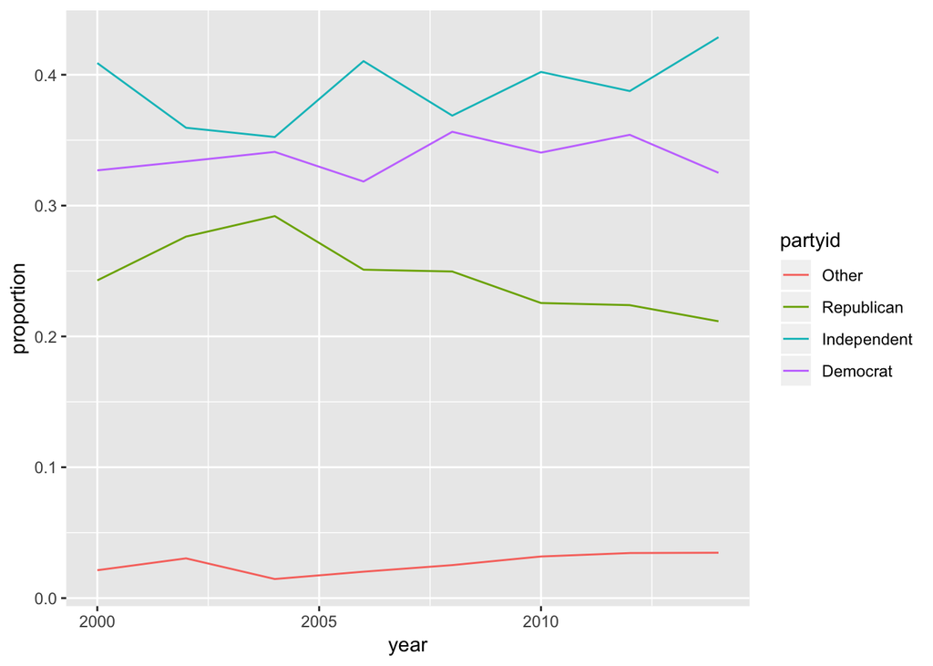

```r
gss_cat %>% mutate(partyid = fct_collapse(partyid, Republican = c("Strong republican", "Not str republican"), Independent = c("Ind,near rep", "Independent", "Ind,near dem"), Democrat = c("Not str democrat", "Strong democrat"), Other = c("No answer", "Don't know", "Other party"))) %>% count(year, partyid) %>% group_by(year) %>% mutate(proportion = n / sum(n)) %>% ggplot(aes(x = year, y = proportion, color =partyid)) + geom_line()
```

## Exercise 2

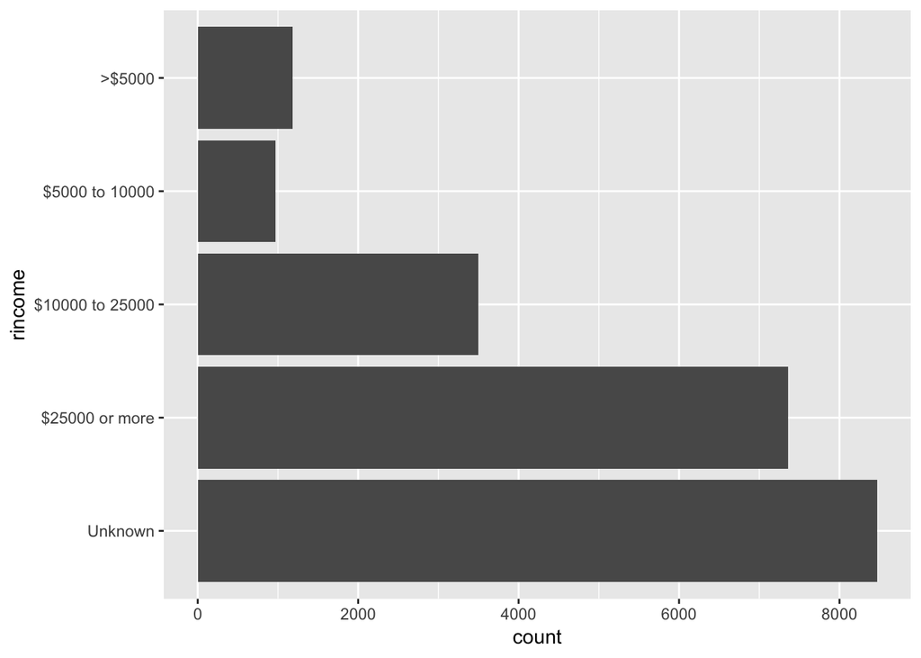

```r
gss_cat %>% mutate(rincome = fct_collapse(rincome, 'Unknown' = c("Don't know", "No answer", "Not applicable", "Refused"), '>$5000' = c("Lt $1000", str_c("$", c("1000", "3000", "4000"), " to ", c("2999", "3999", "4999"))), '$5000 to 10000' = str_c("$", c("5000", "6000", "7000", "8000"), " to ", c("5999", "6999", "7999", "9999")), '$10000 to 25000' = str_c("$", c("10000", "15000", "20000"), " - ", c("14999", "19999", "24999")))) %>% ggplot(aes(x = rincome)) + geom_bar() + coord_flip()
```